# Social Change in Anticipated Caring Roles:

A Portrait of Young Americans’ Views of their Future Selves

Joanna R. Pepin

*University of Toronto*

Melissa A. Milkie

*University of Toronto*

# Background

## Caregiving Ambitions Framework

[Bear 2019](https://journals.aom.org/doi/10.5465/amr.2016.0424)

**Motivation to give care**, across a variety of contexts and over the lifespan, **is central to understanding life goals** and ultimately behavior.

## Expand definition of

## caring roles:

- Caring for a spouse
- In-direct care

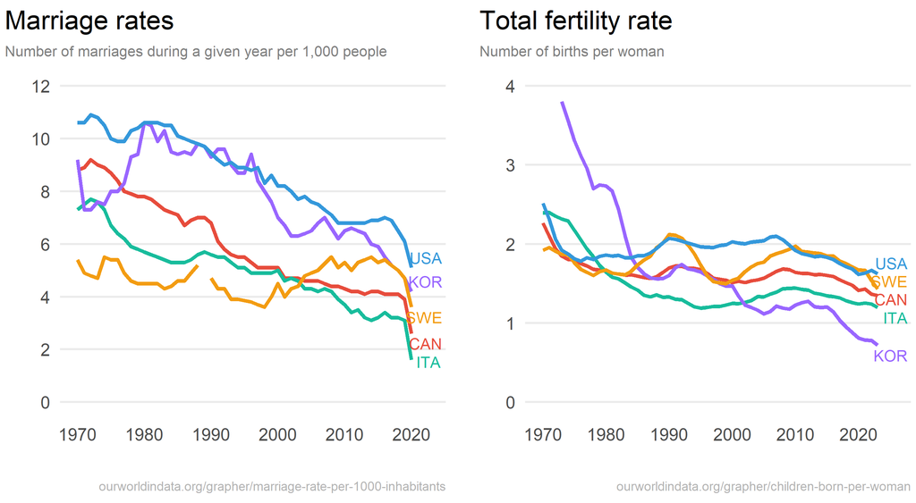

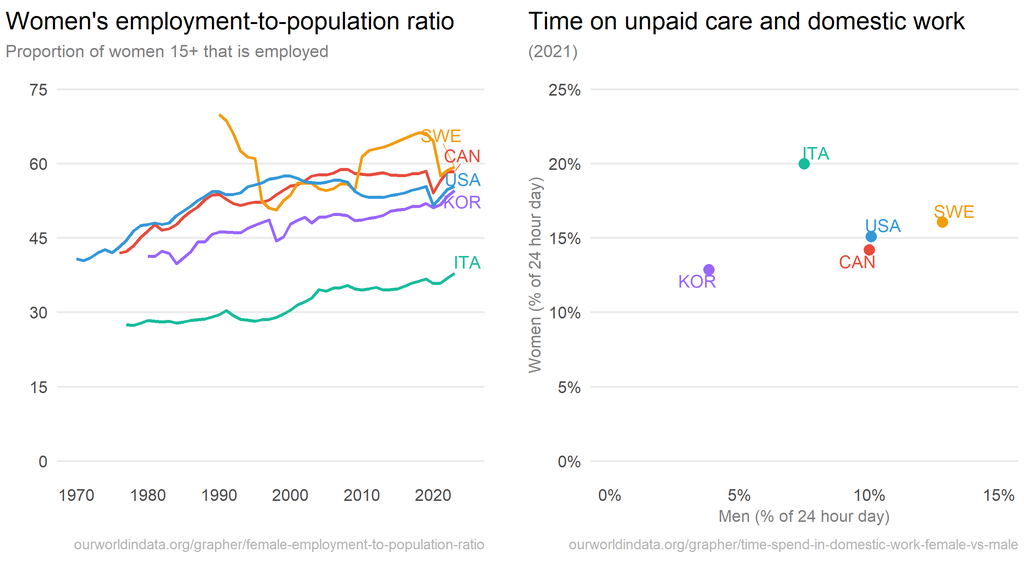

## Research Questions

1. Are there **changes** in youths’ views of their future selves as spouses, parents, and workers?
2. Do these projected future selves vary by **gender**?

# Monitoring the Future Surveys (1976-2023)

*Nationally representative sample of U.S. 12th-graders*  
N = 99,399

https://www.icpsr.umich.edu/web/ICPSR/series/35

These next questions ask you to guess how well you might do in several different situations. **How good do you think you would be as a**:

- **husband or wife?**
- **parent?**
- **worker on a job?**

**Response options**:

1. poor
2. not so good
3. fairly good
4. good
5. very good

## Key IVs

- Year
- Year<sup>2</sup>
- Gender

[figure not shown]

## Sample

| **Variable** | **Overall** N = 99,399 (100%) | **Men** N = 47,369 (48%) | **Women** N = 52,030 (52%) |
| --- | --- | --- | --- |
| Mom completed college | 33% | 34% | 31% |
| Race identity |  |  |  |
| White | 71% | 73% | 70% |
| Black | 11% | 9.4% | 12% |
| Another race | 18% | 18% | 18% |
| Region |  |  |  |
| Northeast | 20% | 19% | 20% |
| Midwest | 27% | 27% | 27% |
| South | 34% | 34% | 34% |
| West | 19% | 19% | 19% |

# Findings

[figure not shown]

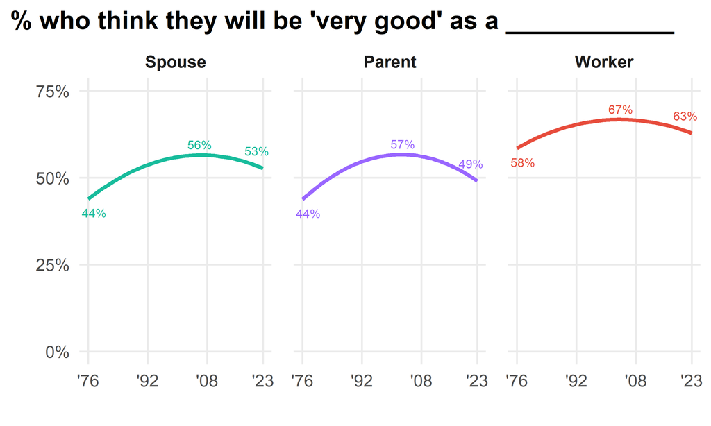

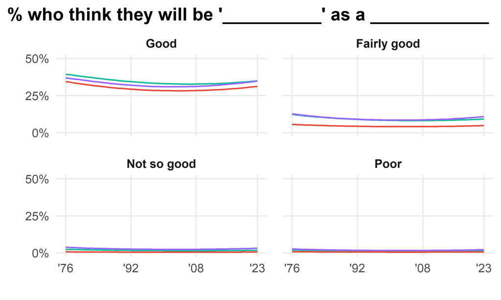

Predicted % from ordinal logistic regression adjusting for gender, mother’s education, race, & region.

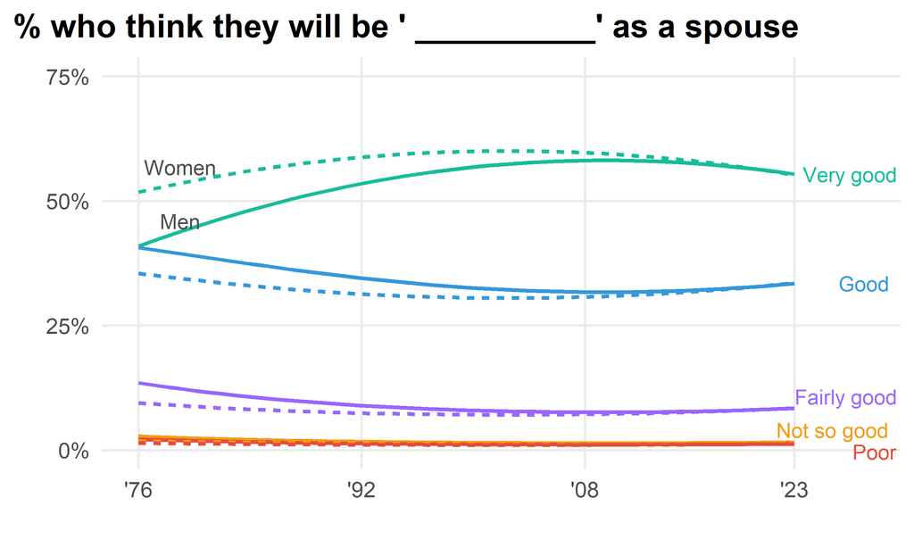

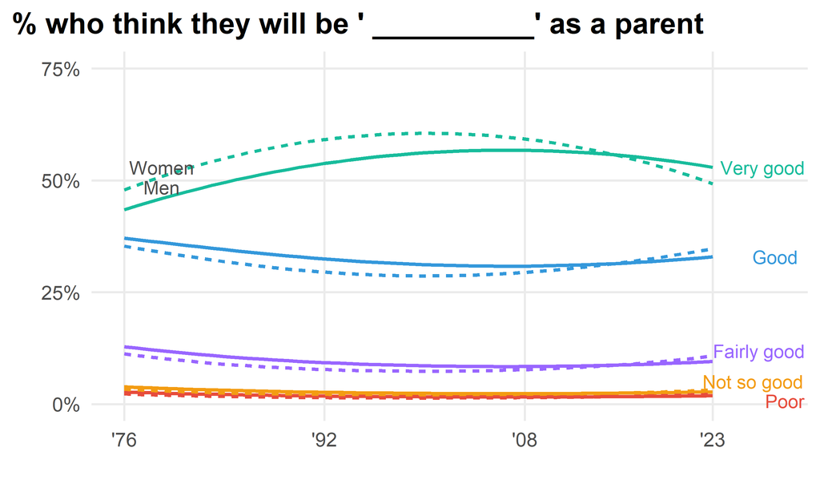

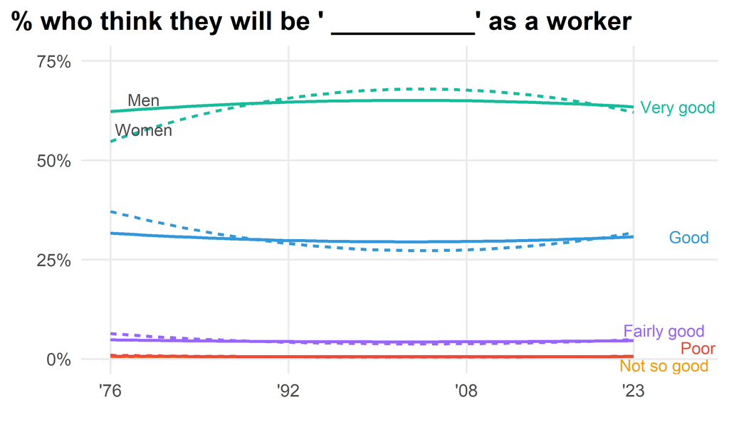

Predicted % from ordinal logistic regression adjusting for mother’s education, race, & region.

# Robustness Check

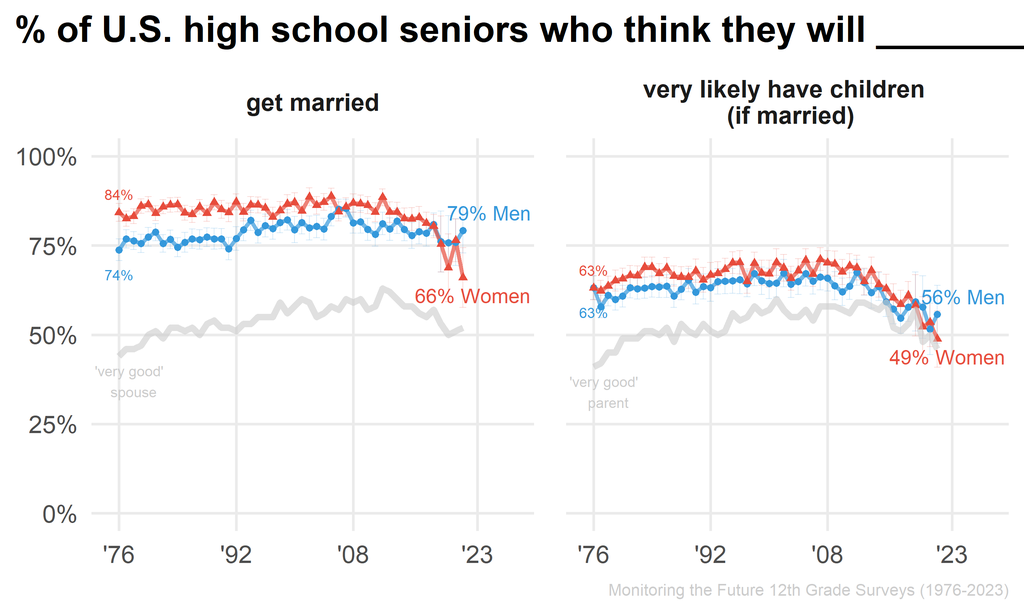

Models adjusted for marital and parenthood expectations

|  | Spouse |  |  |  | Parents |  |  |  |
| --- | --- | --- | --- | --- | --- | --- | --- | --- |
|  | full model |  | with expectations |  | full model |  | with expectations |  |
|  | coef. | S.E. | coef. | S.E. | coef. | S.E. | coef. | S.E. |
| Year | 1.011*** | 0.000 | 1.015*** | 0.001 | 1.009*** | 0.000 | 1.012*** | 0.001 |
| Year2 | 0.999*** | 0.000 | 0.999*** | 0.000 | 0.999*** | 0.000 | 1.000*** | 0.000 |
| Women | 1.217*** | 0.012 | 1.070*** | 0.019 | 1.162*** | 0.012 | 1.174*** | 0.020 |
| Year * Women |  |  | 0.991*** | 0.001 |  |  | 0.996*** | 0.001 |
| Year2 * Women |  |  | 1.000** | 0.000 |  |  | 1.000** | 0.000 |
| Not getting married |  |  | 0.113*** | 0.034 |  |  |  |  |
| I have no idea |  |  | 0.306*** | 0.018 |  |  |  |  |
| Fairly likely |  |  |  |  |  |  | 0.347*** | 0.016 |
| Unlikely/Uncertain |  |  |  |  |  |  | 0.121*** | 0.019 |

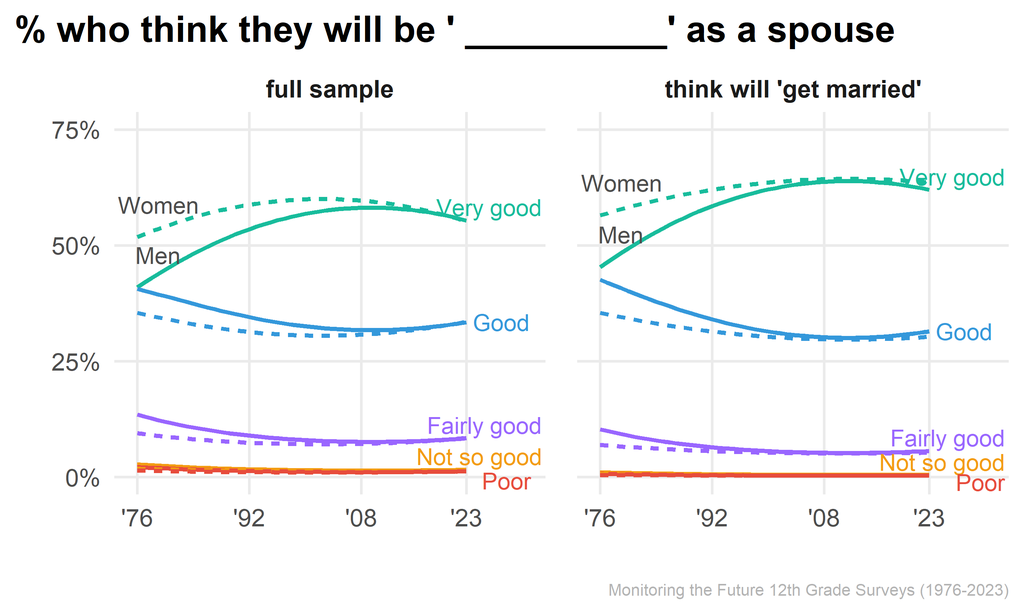

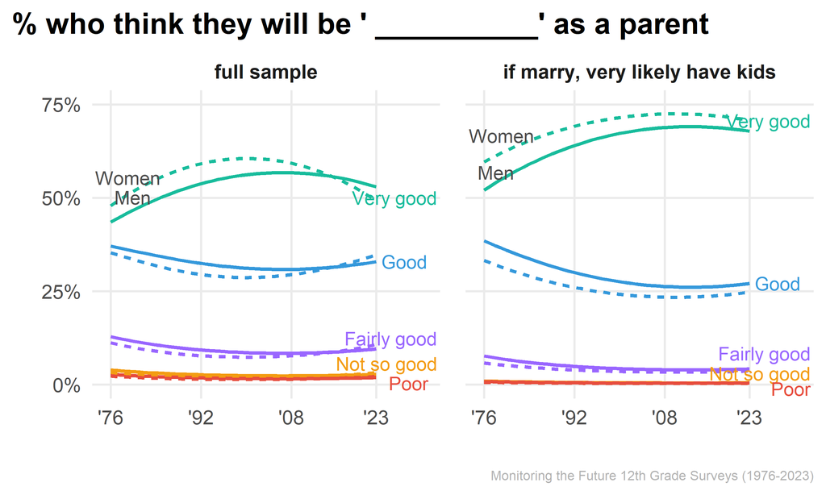

# Conclusion

## Summary

- Greatest **positivity about worker** self
- **Inverse U-shape** with increasingly positivity through 2000s followed by decline
- Strong **gender convergence** over time
- **Next Steps**
  - Identify diversity
  - Link with outcomes

Why did **perceived competencies increase** from 1970s to 2000s?

If social connection in society is diminishing, will youth be “**care ambitious**”?

# Thank you!

Joanna R. Pepin  
*University of Toronto*

Melissa A. Milkie  
*University of Toronto*

[figure not shown]

# Appendix

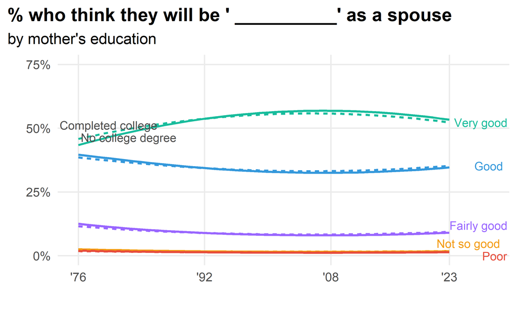

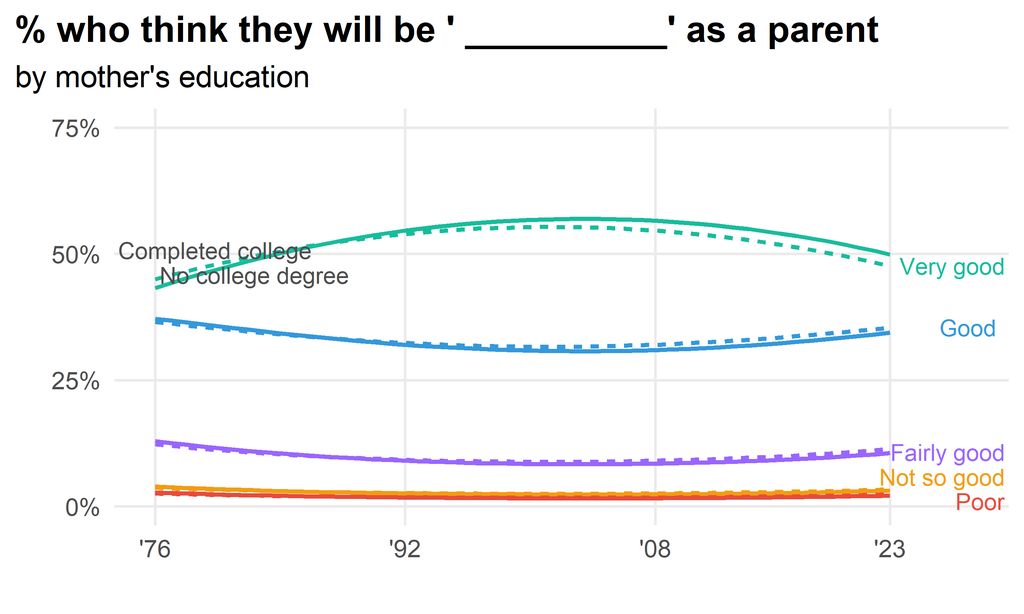

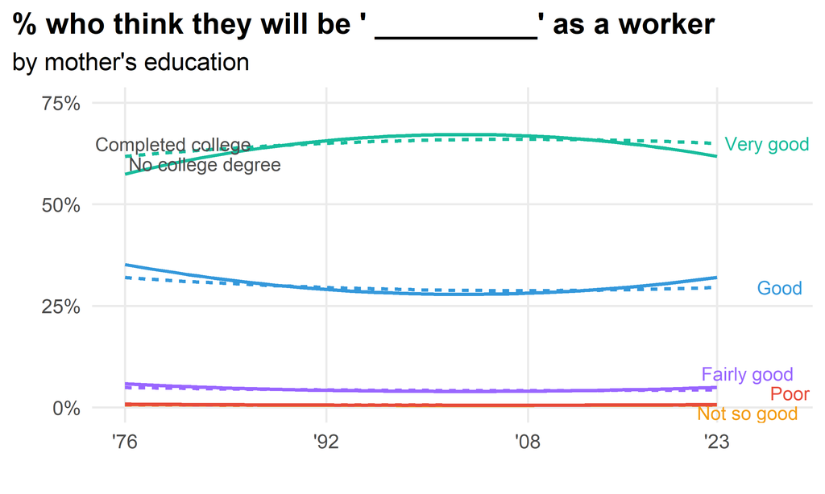

Predicted % from ordinal logistic regression adjusting for gender, race, & region.

[Bear 2019](https://journals.aom.org/doi/10.5465/amr.2016.0424)